# README

## ForestMicroNet: A Forest Microclimate Monitoring Network

### Network Overview

ForestMicroNet is (will be!) a collection of sites using standardized sampling protocols, sensors, and experimental design frameworks to monitor forest microclimates–including measurements of soil moisture, soil temperature, wind speed, wind direction, precipitation, and canopy and surface air temperature and relative humidity. In addition to these measurements, coincident and collocated measurements of forest structural diversity will be taken.

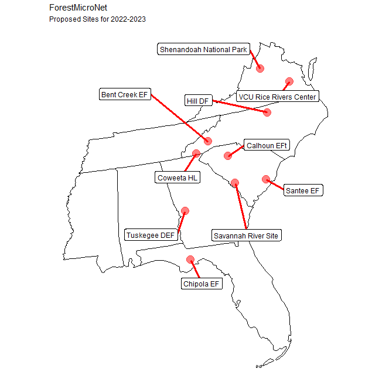

### Why monitor forest microclimates?

Understanding the magnitude and spatial variability of current and future climate in southeastern US forests is key to maintaining forest health, productivity, and habitat provision. However, adequate characterization of climate variability at management relevant spatial scales (10s to 100s of square meters) is hindered by an overreliance on gridded climate data (with resolutions of 10s of hectares to 10s of square kilometers) which are informed by networks of free-air weather stations, typically located in open fields, far from forests. Such positioning may negate any influence of local effects created by forests or topography including localized microclimates that are decoupled from broader climatic patterns. Remotely sensed data often lack the necessary spatiotemporal resolution to resolve this problem, resulting in biases or limitations to the use of many climate data products to inform forest-relevant research and management. A baseline understanding of local effects— specifically how microclimates vary in space and time—is necessary to climate mitigation efforts.

To address this need, we propose the creation of a forest microclimate monitoring network using a uniform, fractal sampling design with standardized measurements of microclimatological variables across multiple USFS Experimental Forests and cooperating forests within the Southern Research Station region.

### Experimental Design

ForestMicroNet is in partnership with the [Ecological Fractal Network](https://ecofracnetwork.github.io/) and follows their fractal plot design as closely as possible.

Contact Jeff Atkins jeffrey.atkins@usda.gov for more information.

This project is funded by the USDA Forest Service Southern Research Station

[figure not shown]